# Exploratory SEMs

Lia Ossanna

2022-06-09

# Introduction

- This document explores preliminary structural equation models (SEMs) using different response types of plant cover and diversity.
- Results are presented first, with the code example at the end.
- The left column of SEM diagrams is based on 2021 values. Right column is the difference between 2012 and 2021 (positive values indicate an increase over time).
  - The main response variable is located in the lower lefthand corner of the diagrams; this is what changes between columns.
- Variables:
  - `Width` (`Wdt`): channel width, derived from the standard deviation of LiDAR data, which measure elevation difference from 2011 to 2019; measurement is not very accurate.
  - `up.trt` (`up.`): a categorical variable, indicating if upland treatments were present (Channel 19).
  - `inch.trt` (`in.`): a categorical variable, indicating if in-channel treatments were present (Channels 13 and 21).
  - `Elev_Diff` (`E_D`): elevation difference from 2011 to 2019, as measured by LiDAR. Some stations could not be measured, so including this variable means the sample size decreases.
  - `OM_perc` (`OM_`): organic matter percent from 2021 soil samples.
  - `TN_log` (`TN_`): total nitrogen content from 2021 soil samples, log-transformed to improve normality.
- Response variables:
  - Total cover
    - `Cvr`: 2021 total cover.
    - `tt.`: difference between 2012 and 2021 total cover.
  - Herbaceous cover
    - `Hrb`: 2021 herbaceous cover.
    - `hr.`: difference between 2012 and 2021 herbaceous cover.
  - Woody cover
    - `Wdy`: 2021 woody cover.
    - `wd.`: difference between 2012 and 2021 woody cover.
  - Perennial species richness
    - `rch`: 2021 richness.
    - `rc.`: difference between 2012 and 2021 richness.
  - Perennial Shannon diversity
    - `shn`: 2021 Shannon diversity
    - `sh.`: difference between 2012 and 2021 Shannon diversity.
- The data sheet for Channel 19 Station 2 + 4 is missing for 2012, so that station is dropped from all models that use the difference between 2012 and 2021.

# Model 5-6: `Width`, `up.trt`, `inch.trt`, `Elev_Diff`, `OM_perc`, `TN_log`

- All variables used.

## Total cover

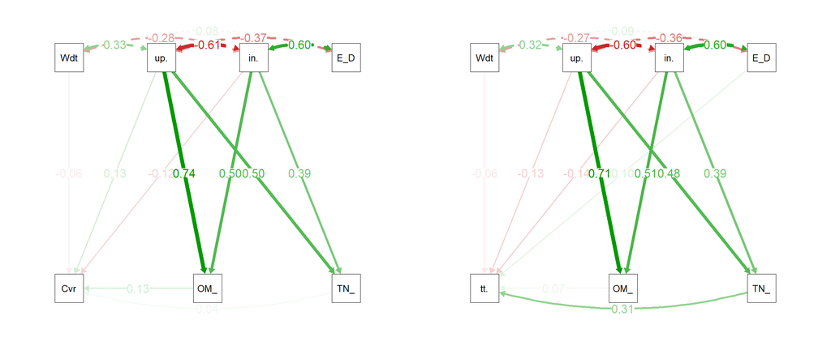

## Herbaceous cover

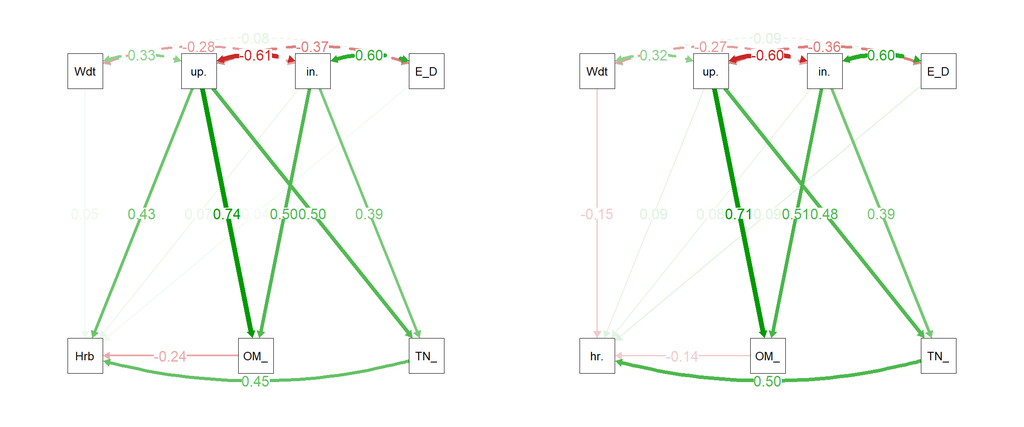

## Woody cover

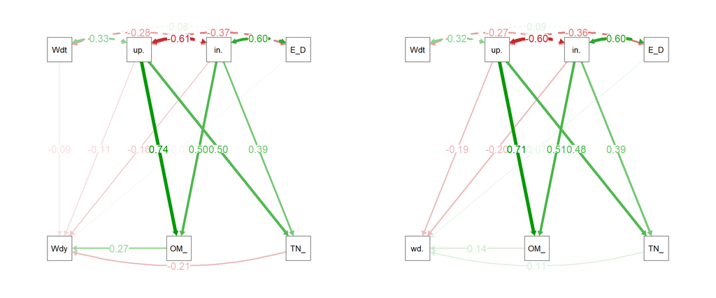

## Richness

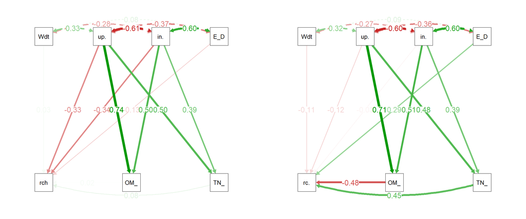

## Shannon diversity

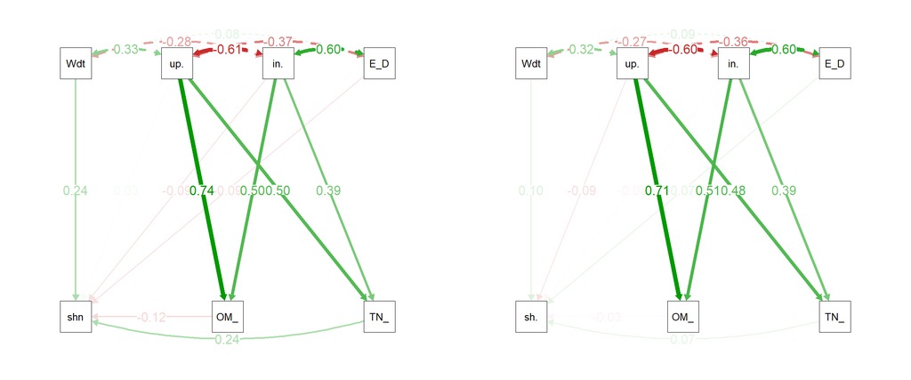

# Model 9-10: `up.trt`, `inch.trt`, `OM_perc`, `TN_log`

- No GIS-derived variables included.

## Total cover

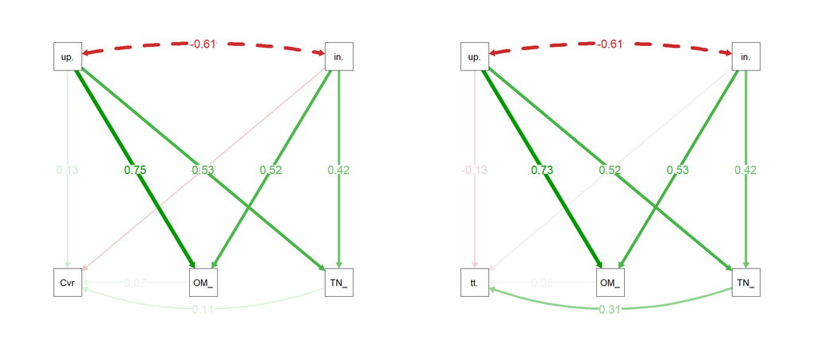

## Herbaceous cover

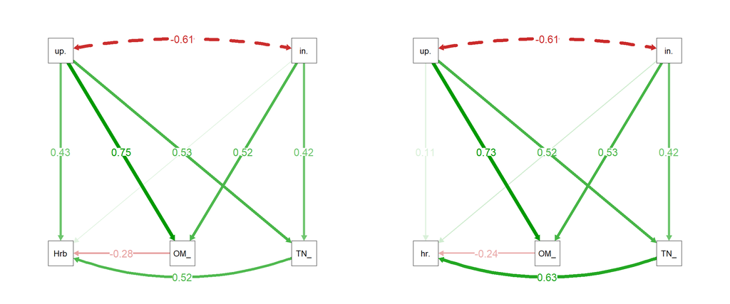

## Woody cover

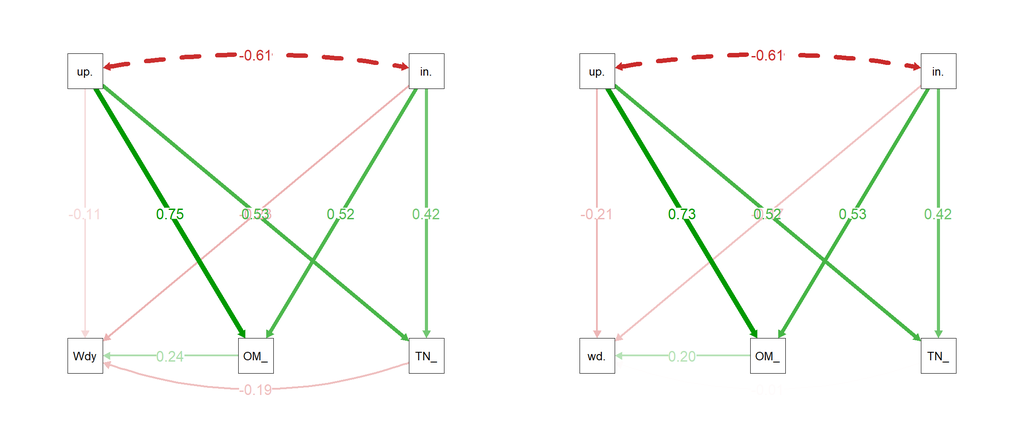

## Richness

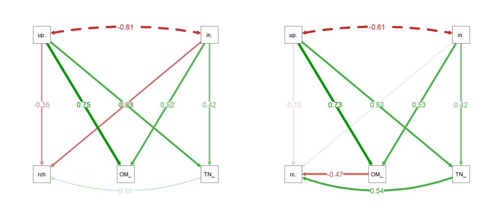

## Shannon diversity

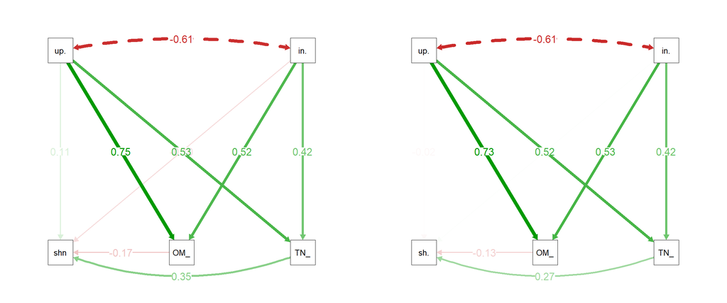

# Model 1-2: `Width`, `up.trt`, `inch.trt`, `Elev_Diff`, `OM_perc`

## Total cover

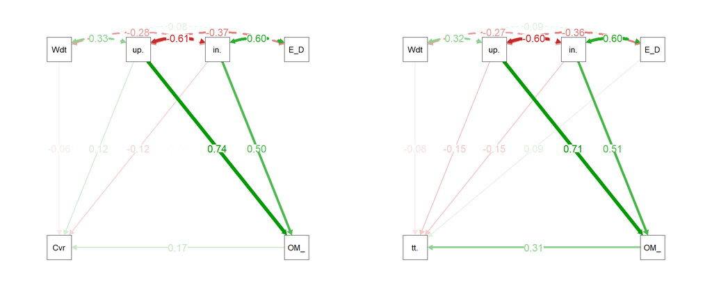

## Herbaceous cover

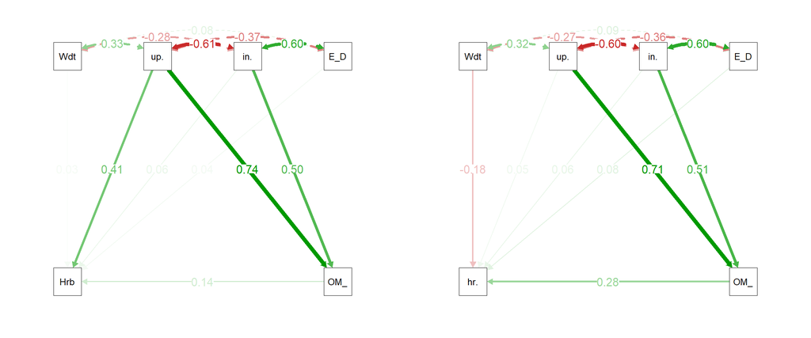

## Woody cover

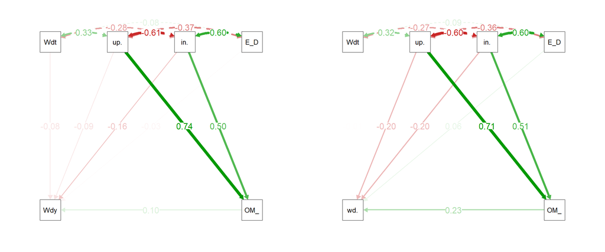

## Richness

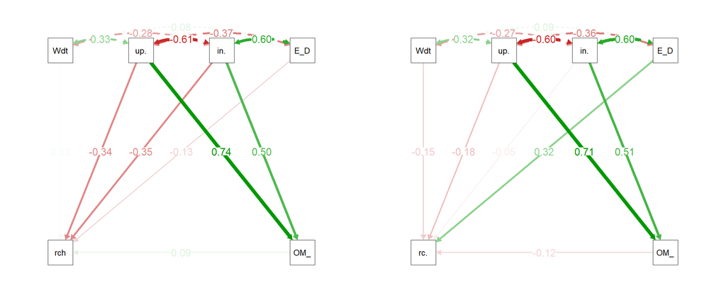

## Shannon diversity

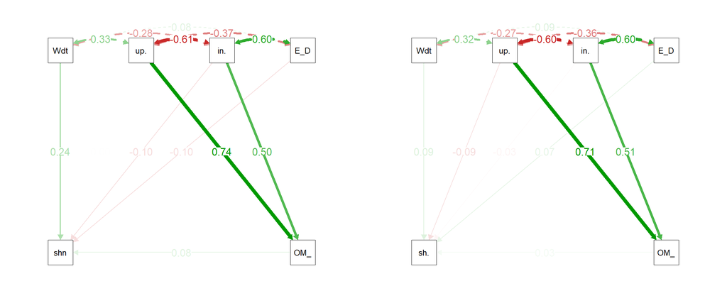

# Model 3-4: `Width`, `inch.trt`, `Elev_Diff`, `OM_perc`

## Total cover

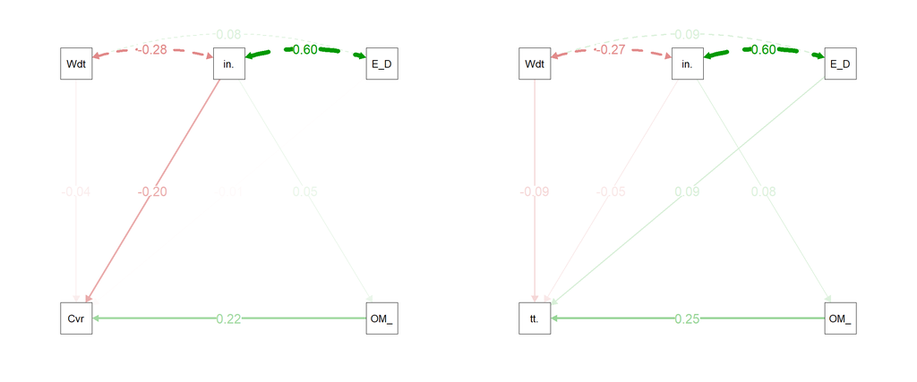

## Herbaceous cover

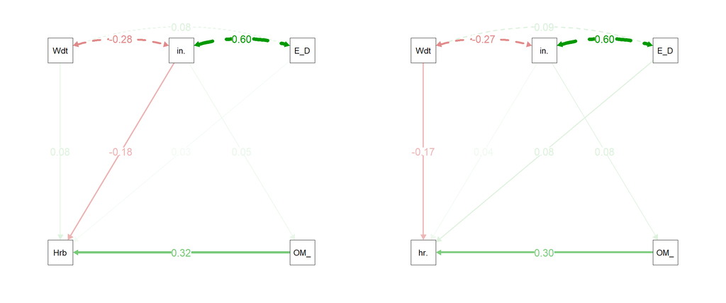